# DATASCI 151 - Introduction to Statistical Computing II

Lecture 06 - For and While Loops

Danilo Freire

danilo.freire@emory.edu

Department of Data and Decision Sciences  
Emory University

# Nice to see you all! 😊

# Brief recap 📚

## Recap: conditional statements and lists

In our last lecture, we covered conditional statements:

- `if`: executes a block of code if a condition is `True`
- `elif`: checks a new condition if previous `if`/`elif` conditions were `False`
- `else`: executes a block of code if all preceding conditions were `False`

We also looked at:

- Combining conditions with logical operators `and`, `or`, `not`
- Nested `if` statements: one `if` inside another for more complex decisions
- List basics: `[None] * n` for placeholders, `list[i]` for indexing (0-indexed!)
- Growing lists with `.append()` and `.extend()`
- Counting elements with `len()`

## Recap: conditional example

Remember this kind of structure?

```python
age = 22
is_student = True
has_scholarship = False

# Eligible if (under 25 AND a student) OR if has a scholarship
if (age < 25 and is_student) or has_scholarship:
    print("Eligible for programme discount.")
else:
    print("Not eligible for programme discount.")
```

The ability to control program flow based on conditions is very important, and loops will build upon this by allowing us to repeat actions 🤓

# For loops in Python 🔄🐍

## What is a `for` loop?

- A `for` loop is a way to iterate over a sequence of elements
- It is a very useful tool to automate repetitive tasks
- The syntax is similar to an `if` statement, including the colon `:` and the necessary indentation (4 spaces)
- The syntax is as follows:

```
for element in sequence:
    body
```

```python
variable = [1,2,3,4]

for i in variable:
    print(i)
```

```
1
2
3
4
```

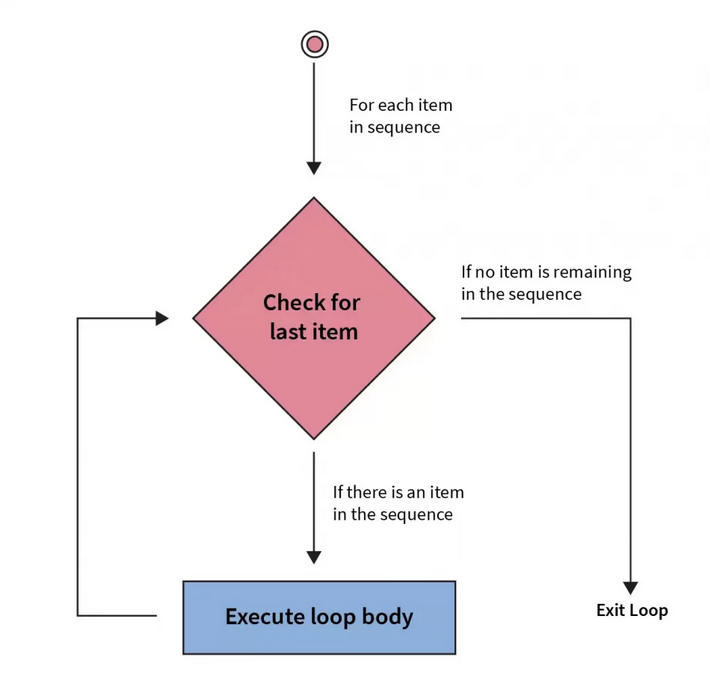

## What can you do with a `for` loop?

- You can iterate over any sequence of elements
  - The elements can be numbers, strings, lists, or any other type of object
- You can even iterate over a list of lists (nested lists) 🤯
  - This is very useful when working with dataframes or matrices

```python
students_scores = [
    ["Alice", 85, 90, 88],
    ["Bob", 78, 82, 84],
    ["Charlie", 92, 95, 93]
]

for i in students_scores:
    print(i)
```

```
['Alice', 85, 90, 88]
['Bob', 78, 82, 84]
['Charlie', 92, 95, 93]
```

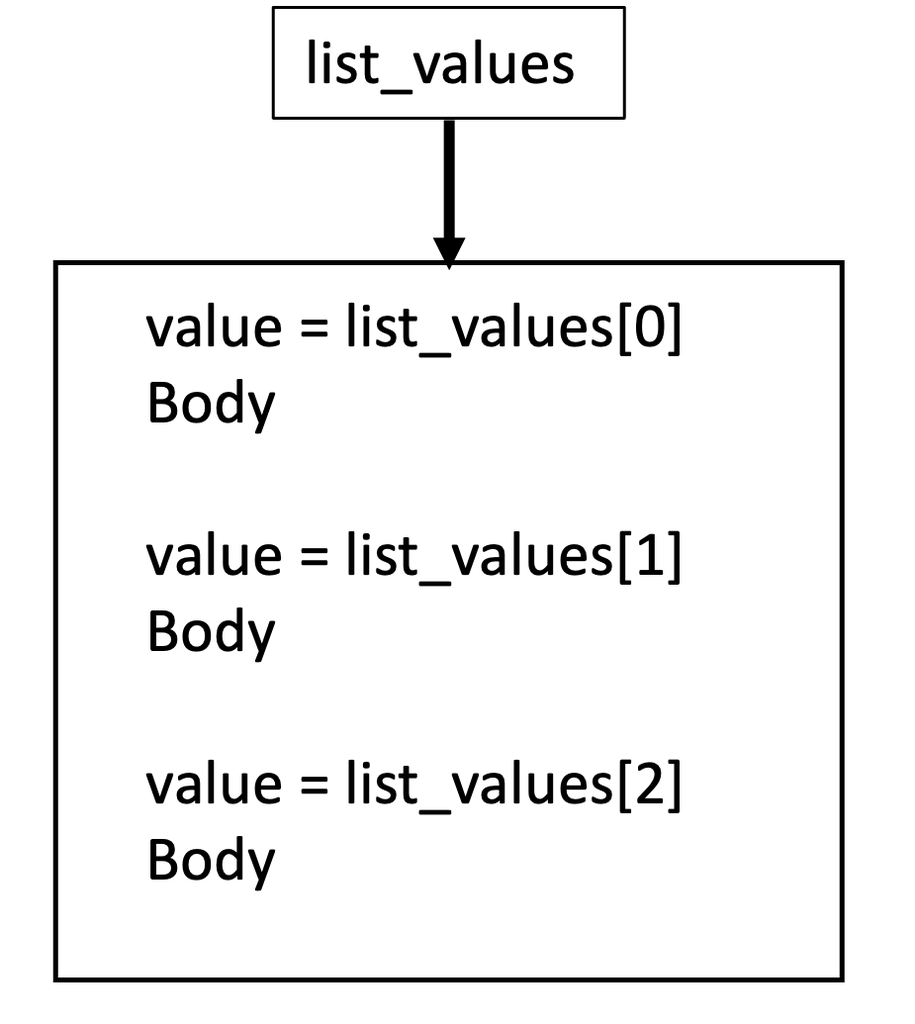

## Some examples

```python
list_ids = ["KIA", "Ferrari", "Ford", "Tesla"]
print(f"Dear customer, we are writing about your {list_ids[0]} car.")
print(f"Dear customer, we are writing about your {list_ids[1]} car.")
print(f"Dear customer, we are writing about your {list_ids[2]} car.")
print(f"Dear customer, we are writing about your {list_ids[3]} car.")
```

```
Dear customer, we are writing about your KIA car.
Dear customer, we are writing about your Ferrari car.
Dear customer, we are writing about your Ford car.
Dear customer, we are writing about your Tesla car.
```

- This is boring! 🥱

```python
list_ids = ["KIA", "Ferrari", "Ford", "Tesla"]

for i in list_ids:
    print(f"Dear customer, we are writing about your {i} car.")
```

```
Dear customer, we are writing about your KIA car.
Dear customer, we are writing about your Ferrari car.
Dear customer, we are writing about your Ford car.
Dear customer, we are writing about your Tesla car.
```

- This is better! 😎

## You can also iterate over additional elements

- This code iterates over `list_ids` plus three extra elements: `'a'`, `'b'`, and `'c'`
- The `+` operator concatenates `list_ids` with `['a', 'b', 'c']`
- For each element in the combined list, the loop assigns it to `id`
- Then `print(id)` displays the value

```python
for id in list_ids + ['a', 'b', 'c']:
    print(id)
```

```
KIA
Ferrari
Ford
Tesla
a
b
c
```

## Iterating with `range()`

The `range()` function is often used with `for` loops to generate a sequence of numbers

- `range(stop)`: Generates numbers from 0 up to (but not including) `stop`

  ```python
  for i in range(5): # Generates 0, 1, 2, 3, 4
      print(i)
  ```

  ```
  0
  1
  2
  3
  4
  ```

- `range(start, stop)`: Generates numbers from `start` up to (but not including) `stop`

  ```python
  for i in range(2, 5): # Generates 2, 3, 4
      print(i)
  ```

  ```
  2
  3
  4
  ```

- `range(start, stop, step)`: Generates numbers from `start` up to (but not including) `stop`, with an increment of `step`

  ```python
  for i in range(2, 8, 2): # Generates 2, 4, 6
      print(i)
  ```

  ```
  2
  4
  6
  ```

## Comparing each value with the previous

- A useful pattern when you need to look at each value alongside the one before it
- `range()` makes this easy because the index `i` also lets you reach `i-1`
- Start the loop at index 1, since index 0 has no “previous”
- Use `temperatures[i]` for the current value and `temperatures[i-1]` for the previous
- Common in data science: daily returns, growth rates, week-over-week changes

```python
temperatures = [22, 24, 23, 27, 26, 30, 28]

for i in range(1, len(temperatures)):
    change = temperatures[i] - temperatures[i-1]
    print(f"Day {i}: temperature changed by {change}°C")
```

```
Day 1: temperature changed by 2°C
Day 2: temperature changed by -1°C
Day 3: temperature changed by 4°C
Day 4: temperature changed by -1°C
Day 5: temperature changed by 4°C
Day 6: temperature changed by -2°C
```

## Iterating over strings

Strings are sequences of characters, so you can iterate over them directly:

```python
course_name = "DATASCI 151"
for char in course_name:
    print(char)
```

```
D
A
T
A
S
C
I

1
5
1
```

This is useful for character-by-character processing, such as counting letters or checking for specific characters

## Using `enumerate()`

When you need both the index and the value during a loop, use `enumerate()`. It yields `(index, value)` pairs on each step.

- Indices start at 0 by default, but `enumerate(variable, start=1)` gives friendlier numbering (“Customer 1, Customer 2, …”)
- Works with any iterable: lists, strings, tuples, even `range()`

```python
fruits = ["apple", "banana", "cherry"]
for index, fruit in enumerate(fruits):
    print(f"Index {index}: {fruit}")
```

```
Index 0: apple
Index 1: banana
Index 2: cherry
```

## Customised messages + numbering

- You can also include numbers in your messages
- Initialise `index = 1` before the loop (just to start at 1, since Python indexes start at 0)
- Add `index = index + 1` at the end of the body

```python
list_ids = ["KIA", "Ferrari", "Ford", "Tesla"]

index = 1
print(f"We are out of the loop {index}")
for i in list_ids:
    print(f"Dear customer, your position is {index} on the waitlist and your car brand is {i}")
    index = index + 1
    print(f"We are inside the loop {index}")
```

```
We are out of the loop 1
Dear customer, your position is 1 on the waitlist and your car brand is KIA
We are inside the loop 2
Dear customer, your position is 2 on the waitlist and your car brand is Ferrari
We are inside the loop 3
Dear customer, your position is 3 on the waitlist and your car brand is Ford
We are inside the loop 4
Dear customer, your position is 4 on the waitlist and your car brand is Tesla
We are inside the loop 5
```

## Another example

```python
for i in range(len(list_ids)):
    print("Dear customer, your position is " + str(i+1) + " on the waitlist" +
           " and your car brand is " + list_ids[i])
```

```
Dear customer, your position is 1 on the waitlist and your car brand is KIA
Dear customer, your position is 2 on the waitlist and your car brand is Ferrari
Dear customer, your position is 3 on the waitlist and your car brand is Ford
Dear customer, your position is 4 on the waitlist and your car brand is Tesla
```

- Who can explain to me what `range(len(list_ids))` does?
- And what does `str(i+1)` do?
- Appendix 01

## `for i in list` vs `for i in range(len(list))`

- The same loop variable `i` can mean two different things
- Always ask: *what does Python put into `i` on each pass?* Printing `i` directly shows the answer

Loop directly over the values

- `i` becomes each *item* of the list in turn: `"KIA"`, `"Ferrari"`, `"Ford"`, `"Tesla"`

```python
list_ids = ["KIA", "Ferrari", "Ford", "Tesla"]
for i in list_ids:
    print(i)
```

```
KIA
Ferrari
Ford
Tesla
```

Default to the first form: it is shorter and works on any iterable (lists, strings, dictionaries, generators). Use the second only when you really need the position number

Loop over the positions (indices)

- `i` becomes each *position number*: `0`, `1`, `2`, `3` (because `len(list_ids)` is 4, and `range(4)` produces `0, 1, 2, 3`)

```python
for i in range(len(list_ids)):
    print(i)
```

```
0
1
2
3
```

- When `i` is a position, you still need to fetch the value yourself with `list_ids[i]`:

```python
for i in range(len(list_ids)):
    print(list_ids[i])
```

```
KIA
Ferrari
Ford
Tesla
```

## Saving time while coding!

### How to make your work easier with `for` loops

- Boring 🥱

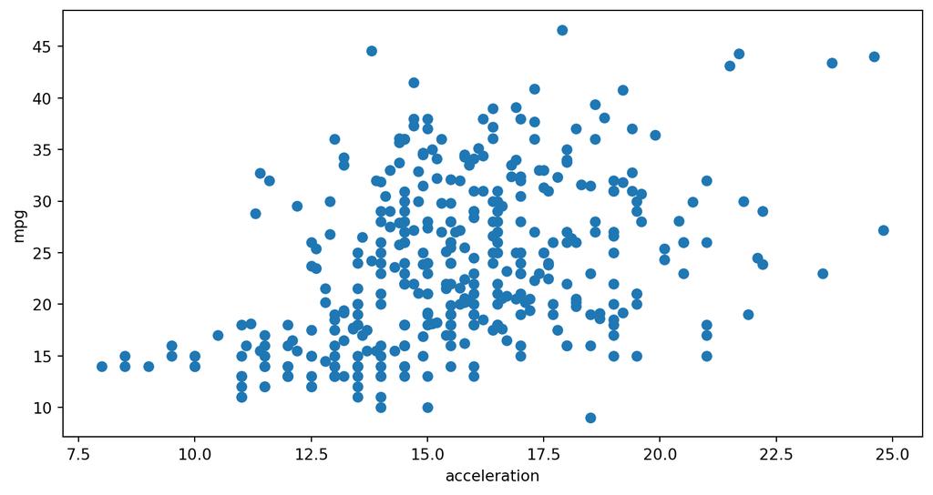

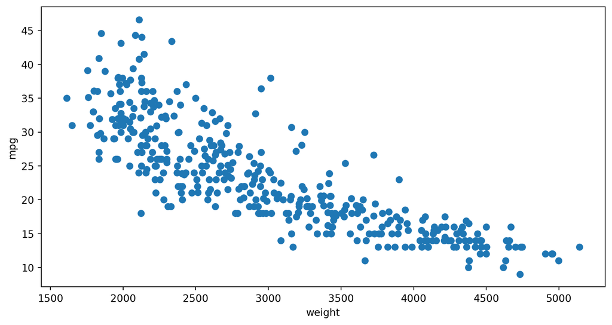

```python
import pandas as pd
import matplotlib.pyplot as plt

carfeatures = pd.read_csv("data/features.csv")
list_vars = ["acceleration","weight"]

variable_name = "acceleration"
plt.scatter(x=carfeatures[variable_name], y=carfeatures["mpg"])
plt.ylabel("mpg")
plt.xlabel(variable_name)
plt.show()

variable_name = "weight"
plt.scatter(x=carfeatures[variable_name], y=carfeatures["mpg"])
plt.ylabel("mpg")
plt.xlabel(variable_name)
plt.show()
```

## Cool 😎

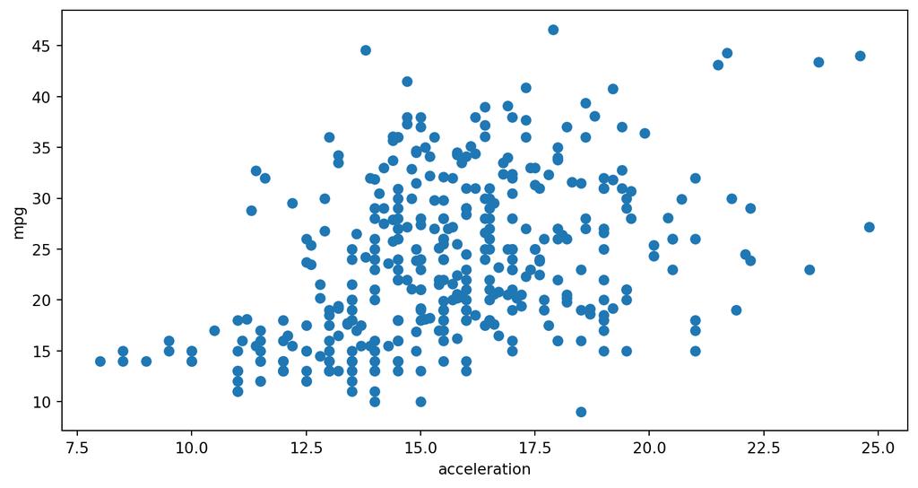

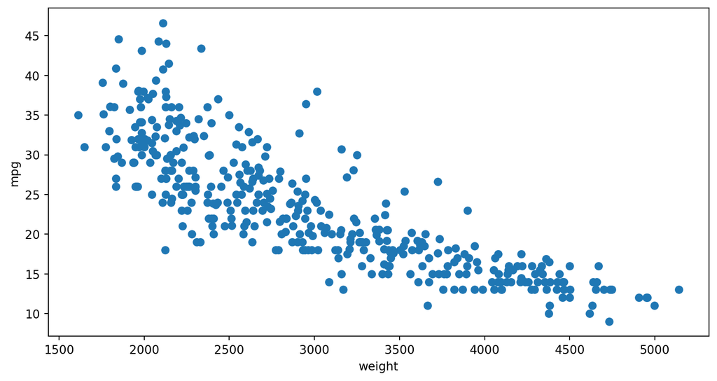

```python
carfeatures = pd.read_csv("data/features.csv")
list_vars = ["acceleration","weight"]

for variable_name in list_vars:
    plt.scatter(x=carfeatures[variable_name], y=carfeatures["mpg"])
    plt.ylabel("mpg")
    plt.xlabel(variable_name)
    plt.show()
```

## Even cooler! 🤩

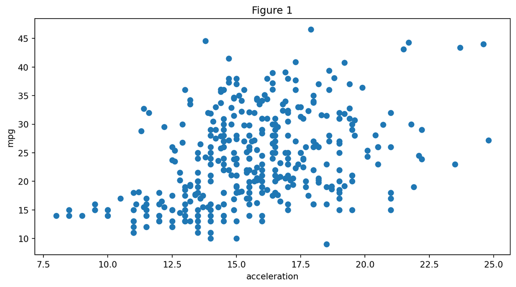

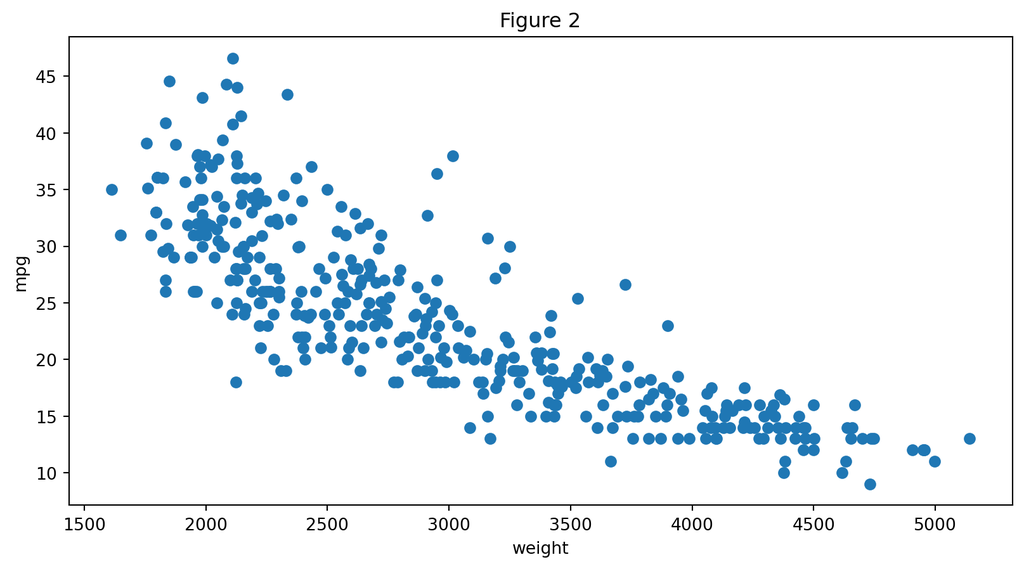

```python
carfeatures = pd.read_csv("data/features.csv")
list_vars   = ["acceleration","weight"]

index = 1
for variable_name in list_vars:
    plt.scatter(x=carfeatures[variable_name], y=carfeatures["mpg"])
    plt.ylabel("mpg")
    plt.xlabel(variable_name)
    plt.title(f"Figure {index}")
    plt.show()
    index = index + 1
```

## Solving many equations at once

- Solve the equation $y = x^2 + 2x$ for $x = 1, 2, 3, \dots, 10$

```
[3, 8, 15, 24, 35, 48, 63, 80, 99, 120]
```

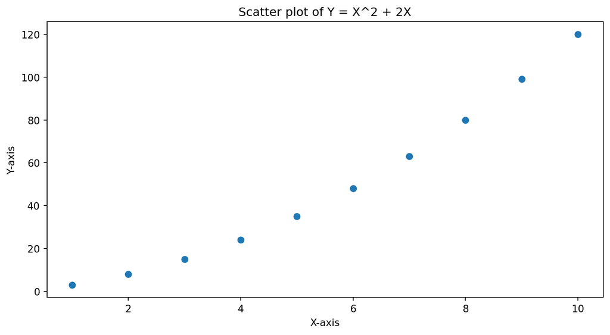

```python
# Create a list of x-values from 1 to 10
# Create a list of y-values to fill in later.

list_x = [1,2,3,4,5,6,7,8,9,10]
list_y = [None] * len(list_x)

# Create an index
index = 0
for x in list_x:
    list_y[index] = list_x[index]**2 + 2*list_x[index]
    index = index + 1

# Display results visually
print(list_y)
plt.scatter(list_x, list_y)
plt.xlabel("X-axis")
plt.ylabel("Y-axis")
plt.title("Scatter plot of Y = X^2 + 2X")
plt.show()
```

## Maths equations using `append`

```
[3, 8, 15, 24, 35, 48, 63, 80, 99, 120]
```

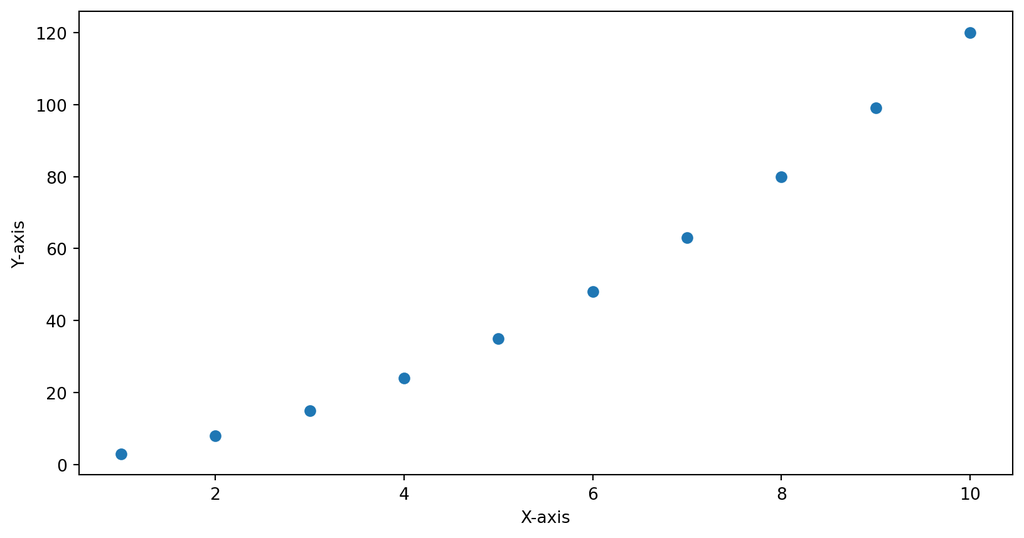

```python
# Create a list of x-values from 1 to 10
# Start an empty list of y-values with []

list_x = [1,2,3,4,5,6,7,8,9,10]
list_y = []

# No index needed - we append each y to list_y as we go
for x in list_x:
    y = x**2 + 2*x
    list_y.append(y)

# Display results visually
print(list_y)
plt.scatter(list_x, list_y)
plt.xlabel("X-axis")
plt.ylabel("Y-axis")
plt.show()
```

## Try it yourself! 🧠

- There are two datasets in the `data` folder:
  - `features.csv`
  - `worldbank_wdi_2019.csv`
- Create a new object called `list_datasets` and assign it a list with the two dataset names
- Run a for loop over this list:
  - Read each of the datasets using `pd.read_csv()`
  - Print a table of descriptive statistics for each dataset
- Appendix 02

# While loops in Python ⏳🐍

## What is a `while` loop?

- A `while` loop is used to iterate over a block of code as long as the test expression (condition) is `True`
- In other words, a `while` loop is a repeated `if` statement that continues to execute until the condition becomes `False`
- We use `while` loops when we don’t know the number of times to iterate beforehand, or when the iteration depends on a condition being met
- Syntax:

```
while test_expression:
    Body of while loop
    (must include logic to eventually make test_expression False)
```

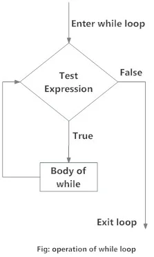

## When to use `while` vs `for`

- `for` loop:
  - Use when you know the number of iterations, or you are iterating over a known sequence (list, string, range, etc.)
  - Example: “Process each item in this list.”
- `while` loop:
  - Use when the number of iterations is not known in advance and depends on a condition becoming `False`
  - Example: “Keep doing this until a certain condition is met (e.g., user enters ‘quit’, or a calculation converges)”
  - Requires careful management of the condition to avoid infinite loops

## `while` loop: simple counter example

This `while` loop acts like `for count in range(5):`

```python
count = 0                       # 1. Initialise a counter variable
while count < 5:                # 2. Set the condition
    print(f"Count is: {count}")
    count = count + 1           # 3. Update the counter (SERIOUSLY! 😂)
print("Loop finished.")

# This could also be written as:
# for count in range(5):
#    print(f"Count is: {count}")
```

```
Count is: 0
Count is: 1
Count is: 2
Count is: 3
Count is: 4
Loop finished.
```

If `count = count + 1` is forgotten, it creates an infinite loop!

## `while` loop: user input validation

`while` loops are great for repeatedly asking for user input until it’s valid

```python
# Example: Get a positive number from the user
# Start with an invalid value so the loop runs at least once

number = -1
while number <= 0:
    try:
        user_input = input("Please enter a positive number: ")
        number = float(user_input) # Try to convert to float
        if number <= 0:
            print("That's not a positive number. Try again.")
    except ValueError:
        print("Invalid input. Please enter a number.")
print(f"You entered a valid positive number: {number}")
```

- The `try`/`except` block catches the error if the user types something that isn’t a number. We will not cover error handling in this course; for now, read it as “if the conversion fails, run this instead”
- This code is best run in a Jupyter Notebook, it fails in a non-interactive environment (like this one) because `input()` doesn’t work here

## Caution: infinite loops!

A common pitfall with `while` loops is creating an infinite loop

- It happens when the condition in the `while` statement never becomes `False`
- This usually occurs when you forget to update the variable(s) inside the loop

Example of an infinite loop (DO NOT RUN THIS CELL AS IS 😅):

```python
count = 0
while count < 5:
    print("Still looping...")
    # Missing count = count + 1
```

- If you accidentally run an infinite loop, you usually need to interrupt the kernel (press `Ctrl+C` in the terminal, or click the “Interrupt Kernel” button in Jupyter)

## Try it yourself!

- You have the following list of fruits: `list_fruits = ["apple", "banana", "cherry", "date", "elderberry"]`
- Write a `while` loop to access the fruit at the current index and print the fruit name
- You can start with the following code:

```python
list_fruits = ["apple", "banana", "cherry", "date", "elderberry"]
index = 0 # Remember, lists are 0-indexed!

# while ... :
    # Add your code here to:
    # 1. Access the fruit at the current index
    # 2. Print the fruit
    # 3. IMPORTANT: Update the index to move to the next fruit!
```

- Appendix 03

# Loop control statements 🚦

## Introduction to loop control

Python has three ways to control the flow inside a loop:

- `break`: exits the loop immediately and skips to whatever comes after it
- `continue`: skips the rest of the current iteration and jumps to the next one
- `else` clause: an optional block that runs only if the loop finished without hitting a `break`

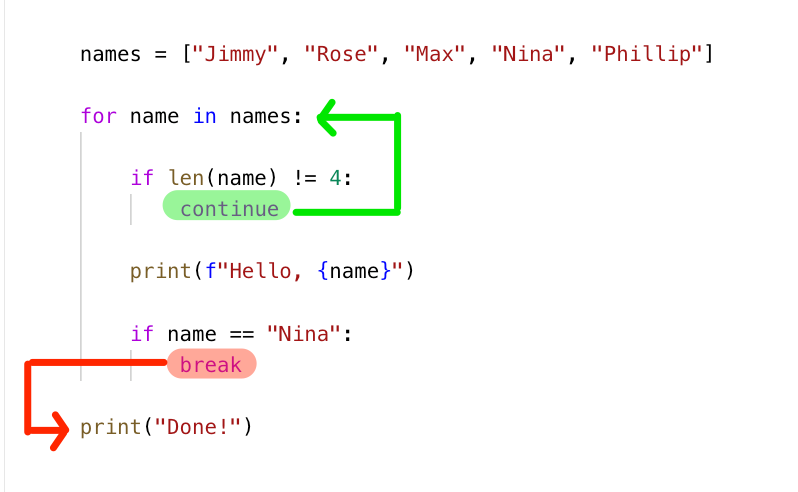

## The `break` statement

- The `break` statement is used to exit a `for` or `while` loop immediately, regardless of whether the loop’s condition is still true or if there are more items to iterate over

Example: Find the first non-integer element in a list and stop the loop

```python
list_mixed = [1, 2, "text_message", 5, 10.5]

for value in list_mixed:
    if not isinstance(value, int): # Check if value is NOT an integer
        print(f"Stopped: Found a non-integer element: '{value}' (type: {type(value).__name__})")
        break # Exit the loop
    print(f"Processing integer: {value}")
print("Loop ended.")
```

```
Processing integer: 1
Processing integer: 2
Stopped: Found a non-integer element: 'text_message' (type: str)
Loop ended.
```

## The `continue` statement

- The `continue` statement is used to skip the remaining code inside the current iteration of a loop and move to the next iteration

Example: Print only integers from a list and skip non-integer elements

```python
list_mixed = [1, 2, "text_message", 5, 10.5, "another_string", 7]

for value in list_mixed:
    if not isinstance(value, int):
        print(f"  Skipping non-integer: '{value}'")
        continue # Skip to the next iteration
    print(f"Integer found: {value}")
print("Loop finished processing all elements.")
```

```
Integer found: 1
Integer found: 2
  Skipping non-integer: 'text_message'
Integer found: 5
  Skipping non-integer: '10.5'
  Skipping non-integer: 'another_string'
Integer found: 7
Loop finished processing all elements.
```

## Loops with an `else` clause

- Both `for` and `while` loops can have an optional `else` clause
- The `else` block runs if and only if the loop terminates normally (i.e., not by a `break` statement)

Example with `for` and `else`: Searching for an item

```python
my_numbers = [1, 3, 5, 7, 9]
search_for = 6

for num in my_numbers:
    if num == search_for:
        print(f"Found {search_for} in the list.")
        break
else: # Executed if the loop completes without a break
    print(f"{search_for} was not found in the list.")

search_for = 5 # Try again with a number that is in the list
for num in my_numbers:
    if num == search_for:
        print(f"Found {search_for} in the list.")
        break
else:
    print(f"{search_for} was not found in the list.")
```

```
6 was not found in the list.
Found 5 in the list.
```

# List comprehensions ⚡️

## What are list comprehensions?

- List comprehensions provide a concise and readable way to create lists
- They often achieve the same result as a `for` loop (and sometimes an `if` condition) but in a single line of code
- Basic syntax: `new_list = [expression for item in iterable]`

Advantages:

- More compact and often easier to read for simple list generations
- Can be more efficient than using a `for` loop with `append()`

## List comprehension examples

Example 1: Customised messages

```python
id_list = ["KIA", "Ferrari", "Ford", "Tesla"]
message_list = ["Your car model is: " + i for i in id_list]
print(message_list)
```

```
['Your car model is: KIA', 'Your car model is: Ferrari', 'Your car model is: Ford', 'Your car model is: Tesla']
```

Example 2: Maths operations

```python
x_list_lc = [1, 2, 3, 4, 5, 6, 7]
x_sqr_list = [x**2 for x in x_list_lc]
print(f"Original list: {x_list_lc}")
print(f"Squared list:  {x_sqr_list}")
```

```
Original list: [1, 2, 3, 4, 5, 6, 7]
Squared list:  [1, 4, 9, 16, 25, 36, 49]
```

## List comprehensions with conditionals

You can add an `if` condition to filter items during list creation

- Syntax with `if`: `new_list = [expression for item in iterable if condition]`

Example: Create a list of squares of only the even numbers from 0 to 9

```python
squares_of_evens = [x**2 for x in range(10) if x % 2 == 0]
print(f"Squares of even numbers from 0-9: {squares_of_evens}")

# Equivalent for loop:
# squares_of_evens_loop = []
# for x in range(10):
#     if x % 2 == 0:
#         squares_of_evens_loop.append(x**2)
# print(squares_of_evens_loop)
```

```
Squares of even numbers from 0-9: [0, 4, 16, 36, 64]
```

## Try it yourself! 🧠

You have a list of names: `names = ["Alice", "Bob", "Charlie", "David", "Eve", "Fiona", "George"]`

1. Using a list comprehension, create a new list called `short_names` that contains only the names from the `names` list that have 5 or fewer characters
2. Using a list comprehension, create a new list called `uppercase_long_names` that contains the uppercase versions of names from the `names` list that have more than 5 characters (use `name.upper()`)
- Appendix 04

# And that’s all for today! 🎉

# Thank you for your attention! 🙏🏽😊

## Appendix 01

1. `range(len(list_ids))`
   - `len(list_ids)` returns the number of items in `list_ids` (4 in our example)
   - `range(4)` then produces the sequence 0, 1, 2, 3
   - So the loop variable `i` takes on each of these index values in turn
2. `str(i+1)`
   - `i` is the current loop index, starting at 0
   - `i+1` shifts the displayed position to match everyday counting (Customer 1, not Customer 0)
   - `str()` converts the result into a string so it can be joined with the rest of the message using `+`

The loop visits each position from 0 to 3, fetches the matching car brand with `list_ids[i]`, and builds a customised message for each customer

Back to the main text

## Appendix 02

```python
import pandas as pd
list_datasets = ["features.csv", "worldbank_wdi_2019.csv"]
for dataset in list_datasets:
    data = pd.read_csv("data/" + dataset)
    print(f"Descriptive statistics for {dataset}:")
    print(data.describe())
    print("\n")
```

```
Descriptive statistics for features.csv:
              mpg   cylinders  displacement       weight  acceleration
count  398.000000  398.000000    398.000000   398.000000    398.000000
mean    23.514573    5.454774    193.427136  2970.424623     15.568090
std      7.815984    1.701004    104.268683   846.841774      2.757689
min      9.000000    3.000000     68.000000  1613.000000      8.000000
25%     17.500000    4.000000    104.250000  2223.750000     13.825000
50%     23.000000    4.000000    148.500000  2803.500000     15.500000
75%     29.000000    8.000000    262.000000  3608.000000     17.175000
max     46.600000    8.000000    455.000000  5140.000000     24.800000


Descriptive statistics for worldbank_wdi_2019.csv:
       life_expectancy  gdp_per_capita_usd
count       252.000000          255.000000
mean         72.682931        17230.949757
std           7.382636        25792.183785
min          52.910000          216.972968
25%          67.109750         2186.046581
50%          73.599000         6837.717826
75%          78.234892        19809.323135
max          85.078049       199377.481800
```

- Back to exercise

## Appendix 03

```python
list_fruits = ["apple", "banana", "cherry", "date", "elderberry"]
index = 0

while index < len(list_fruits):
    current_fruit = list_fruits[index]
    print(current_fruit)
    index = index + 1 # or index += 1
```

```
apple
banana
cherry
date
elderberry
```

- Back to exercise

## Appendix 04: solution for list comprehensions exercise

Solution for the list comprehension “Try it yourself!” exercise:

```python
names = ["Alice", "Bob", "Charlie", "David", "Eve", "Fiona", "George"]

# 1. Names with 5 or fewer characters
short_names = [name for name in names if len(name) <= 5]
print(f"Original names: {names}")
print(f"Short names (<= 5 chars): {short_names}")

# 2. Uppercase versions of names longer than 5 characters
uppercase_long_names = [name.upper() for name in names if len(name) > 5]
print(f"Uppercase long names (> 5 chars): {uppercase_long_names}")
```

```
Original names: ['Alice', 'Bob', 'Charlie', 'David', 'Eve', 'Fiona', 'George']
Short names (<= 5 chars): ['Alice', 'Bob', 'David', 'Eve', 'Fiona']
Uppercase long names (> 5 chars): ['CHARLIE', 'GEORGE']
```

Back to exercise